# Writing new samplers (IPM example)

Perry de Valpine

September 2019

# IPM example

# Example: Woodchat Shrike

Thanks to Michael Schaub for this example. (Where is it from?)

Michael’s summary:

## Available data:

- marray: capture-recapture data in the marray format. It’s a 3D array, the third dimension being the age (juvenile vs. adult)
- count: population counts in each year
- productivity data: vector J is the number of fledglings per year and B is the annual number of surveyed broods which give raise to the number of fledglings.

## Some features of the model:

- based on the life history of a passerine (2 age classes for survival, age at first reproduction = 1 year)
- includes demographic and environmental stochasticity (i.e temporal random effects on all demographic rates)

```r
## Thanks to Michael Schaub for this example

### Setup provided by Michael Schaub
# Example of an integrated population model for a woodchat shrike (passerine bird)

# Available data:
# - marray: capture-recapture data in the marray format. It's a 3D array, the third dimension being the age (juvenile vs. adult)
# - count: population counts in each year
# - productivity data: vector J is the number of fledglings per year and B is the annual number of surveyed broods which give raise to the number of fledglings.

# Some features of the model:
# - based on the life history of a passerine (2 age classes for survival, age at first reproduction = 1 year)
# - includes demographic and environmental stochasticity (i.e temporal random effects on all demographic rates)

##############################################

# Load data
load("WoodchatShrike.Rdata")

# Define a function which produces the necessary values to create a discrete uniform prior in JAGS using dcat
disc.unif <- function(A, B){
  pprob <- c(rep(0, A-1), rep(1/(B-A+1), (B-A+1)))
  return(pprob)
}


## nimble model code,
## slightly modified from JAGS code
ipm_code <- nimbleCode({

  # Priors and linear models
  mean.logit.sj <- logit(mean.sj)
  mean.sj ~ dunif(0, 1)
  mean.logit.sa <- logit(mean.sa)
  mean.sa ~ dunif(0, 1)
  mean.p ~ dunif(0, 1)
  mean.log.f <- log(mean.f)
  mean.f ~ dunif(0, 10)

  for (t in 1:(n.occasions-1)){
    p[t] <- mean.p
  }

  for (t in 1:(n.occasions-1)){
    logit.sj[t] <- mean.logit.sj + eps.sj[t]
    eps.sj[t] ~ dnorm(0, tau.sj)
    sj[t] <- ilogit(logit.sj[t])         # back transformation from logit scale
    logit.sa[t] <- mean.logit.sa + eps.sa[t]
    eps.sa[t] ~ dnorm(0, tau.sa)
    sa[t] <- ilogit(logit.sa[t])
  }

  for (t in 1:(n.occasions)){
    log.f[t] <- mean.log.f + eps.f[t]
    eps.f[t] ~ dnorm(0, tau.f)
    f[t] <- exp(log.f[t])         # back transformation from log scale
  }

  sigma.sj ~ dunif(0, 10)
  tau.sj <- pow(sigma.sj, -2)
  sigma.sa ~ dunif(0, 10)
  tau.sa <- pow(sigma.sa, -2)
  sigma.f ~ dunif(0, 10)
  tau.f <- pow(sigma.f, -2)

  sigma.obs ~ dunif(0.5, 50)
  tau.obs <- pow(sigma.obs, -2)


  # State-space model for count data
  # Model for the initial population size
  N[1,1] ~ dcat(pNinit[])
  N[2,1] ~ dcat(pNinit[])

  # Process model over time
  for (t in 1:(n.occasions-1)){
    N[1,t+1] ~ dpois(sj[t] * f[t] * (N[1,t] + N[2,t]))
    N[2,t+1] ~ dbin(sa[t], (N[1,t] + N[2,t]))
  }

  # Observation model
  for (t in 1:n.occasions){
    count[t] ~ dnorm(N[1,t] + N[2,t], tau.obs)
  }


  # Poisson regression model for productivity data
  for (t in 1:n.occasions){
    J[t] ~ dpois(f[t] * B[t])
  }

  # Capture-recapture model (multinomial likelihood)
  # Define the multinomial likelihood
  for (t in 1:(n.occasions-1)){
    ## nimble needs more explicit indexing, so replace as follows.
    ## (An alternative is to use dimensions argument to nimbleModel.)
    ##   marr.j[t,1:n.occasions] ~ dmulti(pr.j[t,], rel.j[t])
    marr.j[t,1:n.occasions] ~ dmulti(pr.j[t,1:n.occasions], rel.j[t])
    ##    marr.a[t,1:n.occasions] ~ dmulti(pr.a[t,], rel.a[t])
    marr.a[t,1:n.occasions] ~ dmulti(pr.a[t,1:n.occasions], rel.a[t])
  }
  # Define the cell probabilities of the m-arrays
  # Main diagonal
  for (t in 1:(n.occasions-1)){
    q[t] <- 1-p[t]   # Probability of non-recapture
    pr.j[t,t] <- sj[t]*p[t]
    pr.a[t,t] <- sa[t]*p[t]
    # Above main diagonal
    for (j in (t+1):(n.occasions-1)){
      pr.j[t,j] <- sj[t]*prod(sa[(t+1):j])*prod(q[t:(j-1)])*p[j]
      pr.a[t,j] <- prod(sa[t:j])*prod(q[t:(j-1)])*p[j]
    } #j
    # Below main diagonal
    for (j in 1:(t-1)){
      pr.j[t,j] <- 0
      pr.a[t,j] <- 0
    } #j
  } #t
  # Last column: probability of non-recapture
  for (t in 1:(n.occasions-1)){
    pr.j[t,n.occasions] <- 1-sum(pr.j[t,1:(n.occasions-1)])
    pr.a[t,n.occasions] <- 1-sum(pr.a[t,1:(n.occasions-1)])
  } #t


  # Derived parameters
  # Total population size
  for (t in 1:(n.occasions)){
    Ntot[t] <- N[1,t] + N[2,t]
  }
} )


# Bundle data
bugs.data <- list(marr.j = marray[,,1], marr.a = marray[,,2], n.occasions = dim(marray)[2], rel.j = rowSums(marray[,,1]), rel.a = rowSums(marray[,,2]), J = J, B = B, count = count, pNinit = disc.unif(1, 300))

# Initial values
inits <- function(){list(mean.sj = runif(1, 0, 0.5), mean.sa = runif(1, 0.4, 0.6), mean.f = runif(1, 1.3, 2))}

## nimble takes initial values as a list, not a function
## (something we should probably allow)
initsVals <- inits()

# Parameters monitored
parameters <- c("mean.sj", "sj", "sigma.sj", "mean.sa", "sa", "sigma.sa", "mean.p", "mean.f", "f", "sigma.f", "sigma.obs", "N", "Ntot")
```

# Look at the data

```r
bugs.data$marr.a
```

```
##       [,1] [,2] [,3] [,4] [,5] [,6] [,7] [,8] [,9] [,10]
##  [1,]   30    2    0    1    0    0    0    0    0    34
##  [2,]    0   15    6    0    2    0    0    0    0    29
##  [3,]    0    0   23    4    0    0    0    0    0    13
##  [4,]    0    0    0   17    0    1    0    0    0    34
##  [5,]    0    0    0    0   21    4    0    0    0    31
##  [6,]    0    0    0    0    0   19    1    1    0    25
##  [7,]    0    0    0    0    0    0   18    3    1    33
##  [8,]    0    0    0    0    0    0    0   10    5    27
##  [9,]    0    0    0    0    0    0    0    0   14    25
```

```r
bugs.data$marr.j
```

```
##       [,1] [,2] [,3] [,4] [,5] [,6] [,7] [,8] [,9] [,10]
##  [1,]   22    4    1    0    0    0    0    0    0    71
##  [2,]    0   19    2    0    0    0    0    0    0    77
##  [3,]    0    0   20    7    0    0    0    1    0    75
##  [4,]    0    0    0   27    2    1    0    0    0    74
##  [5,]    0    0    0    0   21    5    0    0    0    96
##  [6,]    0    0    0    0    0   25    4    1    0    89
##  [7,]    0    0    0    0    0    0   19    3    0    81
##  [8,]    0    0    0    0    0    0    0   20    6    96
##  [9,]    0    0    0    0    0    0    0    0   23    96
```

```r
bugs.data$B
```

```
##  [1] 62 49 59 69 74 59 60 82 67 72
```

```r
bugs.data$J
```

```
##  [1]  98  95 102 106 118  98  92 128 109 108
```

# Try MCMC and study results

```r
nimbleOptions(verbose = FALSE)
## 1. Build model
ipm_model <- nimbleModel(ipm_code,
                         constants = bugs.data,
                         inits = initsVals)
## 2. Build MCMC configuration and samplers:
ipm_mcmc <- buildMCMC(ipm_model)
## 3. Compile model via generated C++.
Cipm_model <- compileNimble(ipm_model)
## 4. Compile MCMC via generated C++
Cipm_mcmc <- compileNimble(ipm_mcmc, project = ipm_model)
## 5. Run MCMC. (nimble does not natively support multiple chains.)
# MCMC settings
ni <- 3000; nt <- 1; nb <- 1000; nc <- 3
samples <- runMCMC(Cipm_mcmc, niter = ni, nburnin = nb)
```

```
## |-------------|-------------|-------------|-------------|
## |-------------------------------------------------------|
```

```r
colnames(samples)
```

```
##  [1] "N[1, 1]"   "N[2, 1]"   "N[1, 2]"   "N[2, 2]"   "N[1, 3]"
##  [6] "N[2, 3]"   "N[1, 4]"   "N[2, 4]"   "N[1, 5]"   "N[2, 5]"
## [11] "N[1, 6]"   "N[2, 6]"   "N[1, 7]"   "N[2, 7]"   "N[1, 8]"
## [16] "N[2, 8]"   "N[1, 9]"   "N[2, 9]"   "N[1, 10]"  "N[2, 10]"
## [21] "mean.f"    "mean.p"    "mean.sa"   "mean.sj"   "sigma.f"
## [26] "sigma.obs" "sigma.sa"  "sigma.sj"
```

# Study results

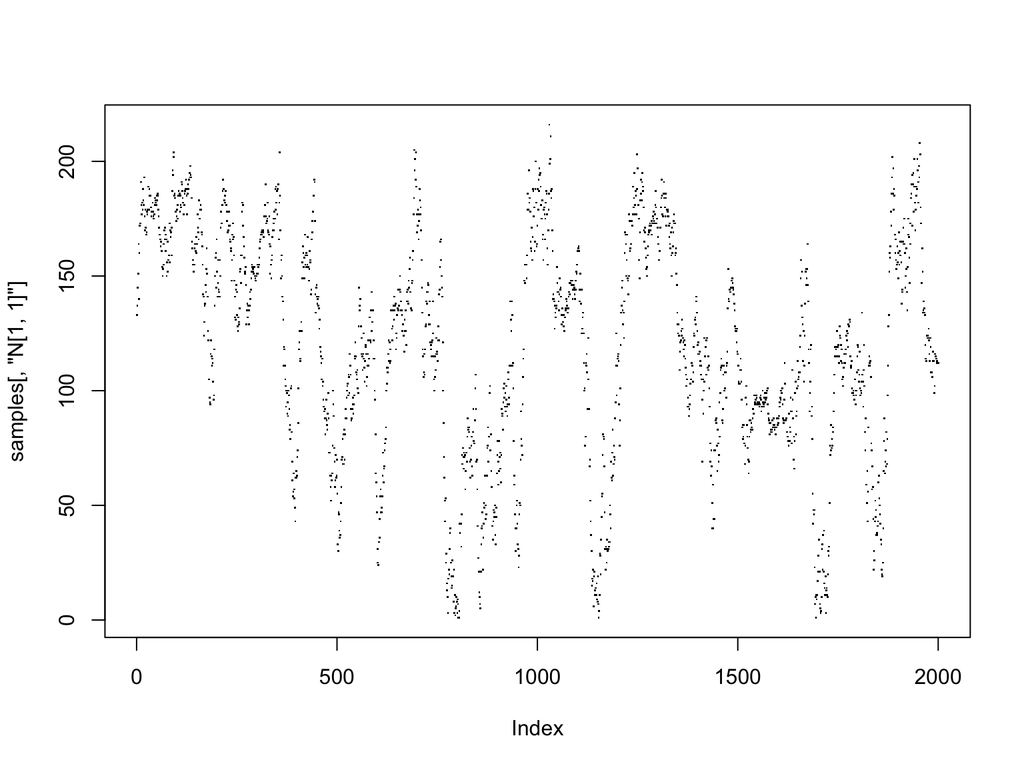

```r
## Pick a few trace plots
plot(samples[,'N[1, 1]'], pch = '.') ## yuck
```

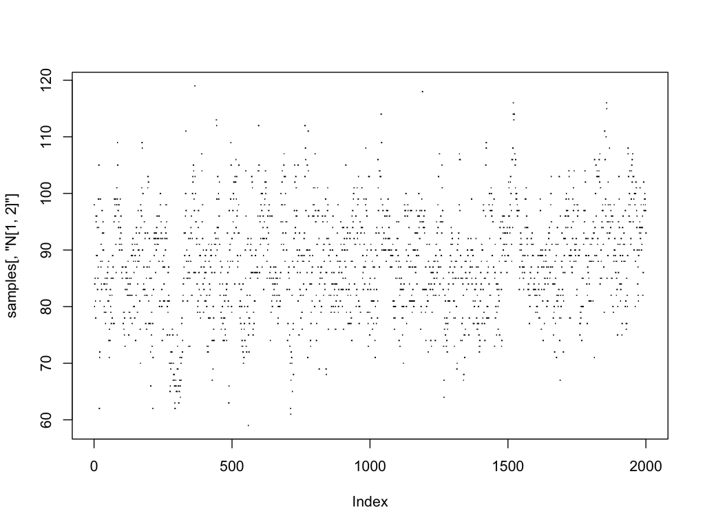

```r
plot(samples[,'N[1, 2]'], pch = '.') ## much better
```

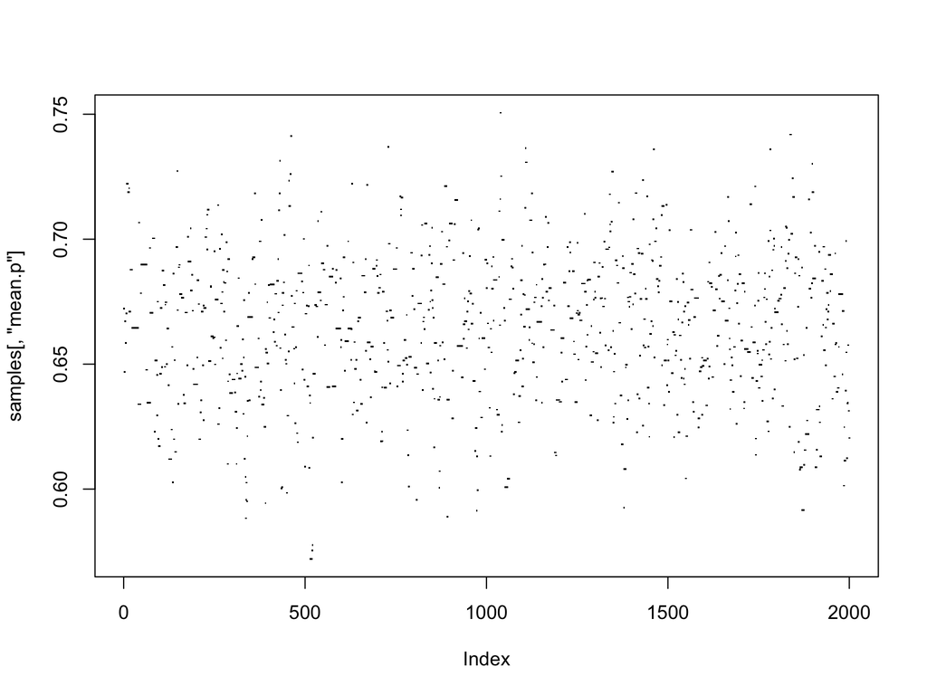

```r
plot(samples[,'mean.p'], pch = '.') ## looks pretty good
```